# Thành viên trong nhóm:

- Trần Tuyên Trường
- Võ Hoàng Nguyên
- Lê Vũ Thế Khôi
- Hoàng Uyên

# Phần 1: Giới thiệu Đồ án

- Bệnh tim mạch là các tình trạng liên quan đến sức khỏe của trái tim, sự hoạt động của các mạch máu gây suy yếu khả năng làm việc của tim. Các bệnh tim mạch bao gồm: các bệnh mạch máu như bệnh động mạch vành, bệnh cơ tim, loạn nhịp tim và suy tim.
- Bệnh tim mạch có thể xảy ra ở mọi độ tuổi, giới tính, nghề nghiệp. Bệnh không thể chữa khỏi hoàn toàn, đòi hỏi sự điều trị và theo dõi cẩn thận (thậm chí là suốt đời), tốn kém nhiều chi phí.
- Theo Tổ chức Y tế Thế giới, hàng năm có đến hơn 17 triệu người tử vong vì bệnh tim mạch. Con số này cho thấy mức độ phổ biến của các bệnh lý về tim là rất cao. Vì vậy nên nhóm em quyết định chọn chủ đề này đồ án cuối kỳ cho môn "Nhập môn lập trình Python cho phân tích".

## Câu hỏi Nghiên cứu chung

- Hút thuốc lá có là nguyên nhân gây ra bệnh tim hay không?
- Sức khỏe hay độ tuổi có làm tăng nguy cơ bị bệnh tim không?
- Sức khỏe tinh thần và thể chất có ảnh hưởng tới việc bị bệnh tim hay không?
- Tìm hiểu các bệnh nền và các chỉ số cơ thể làm ảnh hưởng tới việc bị bệnh tim hay không.
- v.v (Còn cập nhật thêm)

## Dữ liệu của nhóm

- Tập dữ liệu được lấy từ: https://www.kaggle.com/datasets/kamilpytlak/personal-key-indicators-of-heart-disease
- Bộ dữ liệu này được sử dụng để dự đoán liệu một người có khả năng mắc bệnh tim hay không dựa trên các thông số đầu vào như giới tính, tuổi tác, hút thuốc, bia rượu . Mỗi hàng trong dữ liệu cung cấp thông tin liên quan về bệnh nhân.
- Biến phân loại (định tính): HeartDisease, Smoking, AlcoholDrinking, Stroke, DiffWalking, Sex, AgeCategory, Diabetic, PhysicalActivity, GenHealth, Asthma, KidneyDisease, SkinCancer
- Biến số (định lượng): BMI, PhysicalHealth, MentalHealth, SleepTime

# Phần 2 - Dữ liệu

```python
import pandas as pd

data = pd.read_csv('heart_2020_cleaned.csv')
data
```

|  | HeartDisease | BMI | Smoking | AlcoholDrinking | Stroke | PhysicalHealth | MentalHealth | DiffWalking | Sex | AgeCategory | Diabetic | PhysicalActivity | GenHealth | SleepTime | Asthma | KidneyDisease | SkinCancer |
| --- | --- | --- | --- | --- | --- | --- | --- | --- | --- | --- | --- | --- | --- | --- | --- | --- | --- |
| 0 | No | 16.60 | Yes | No | No | 3 | 30 | No | Female | 55-59 | Yes | Yes | Very good | 5 | Yes | No | Yes |
| 1 | No | 20.34 | No | No | Yes | 0 | 0 | No | Female | 80 or older | No | Yes | Very good | 7 | No | No | No |
| 2 | No | 26.58 | Yes | No | No | 20 | 30 | No | Male | 65-69 | Yes | Yes | Fair | 8 | Yes | No | No |
| 3 | No | 24.21 | No | No | No | 0 | 0 | No | Female | 75-79 | No | No | Good | 6 | No | No | Yes |
| 4 | No | 23.71 | No | No | No | 28 | 0 | Yes | Female | 40-44 | No | Yes | Very good | 8 | No | No | No |
| ... | ... | ... | ... | ... | ... | ... | ... | ... | ... | ... | ... | ... | ... | ... | ... | ... | ... |
| 59995 | No | 25.82 | Yes | No | No | 0 | 0 | No | Female | 40-44 | No | Yes | Good | 6 | No | No | No |
| 59996 | No | 29.84 | No | No | No | 0 | 0 | No | Male | 40-44 | No | No | Excellent | 5 | No | No | No |
| 59997 | No | 35.28 | No | No | No | 0 | 0 | No | Female | 35-39 | No | Yes | Good | 8 | No | No | No |
| 59998 | No | 23.44 | Yes | No | No | 0 | 5 | No | Female | 25-29 | No | Yes | Excellent | 5 | No | No | No |
| 59999 | No | 22.59 | No | No | No | 0 | 0 | No | Male | 70-74 | No | Yes | Excellent | 7 | No | Yes | No |

60000 rows × 17 columns

```python
data.info()
```

```
<class 'pandas.core.frame.DataFrame'>
RangeIndex: 60000 entries, 0 to 59999
Data columns (total 17 columns):
 #   Column            Non-Null Count  Dtype
---  ------            --------------  -----
 0   HeartDisease      60000 non-null  object
 1   BMI               60000 non-null  float64
 2   Smoking           60000 non-null  object
 3   AlcoholDrinking   60000 non-null  object
 4   Stroke            60000 non-null  object
 5   PhysicalHealth    60000 non-null  int64
 6   MentalHealth      60000 non-null  int64
 7   DiffWalking       60000 non-null  object
 8   Sex               60000 non-null  object
 9   AgeCategory       60000 non-null  object
 10  Diabetic          60000 non-null  object
 11  PhysicalActivity  60000 non-null  object
 12  GenHealth         60000 non-null  object
 13  SleepTime         60000 non-null  int64
 14  Asthma            60000 non-null  object
 15  KidneyDisease     60000 non-null  object
 16  SkinCancer        60000 non-null  object
dtypes: float64(1), int64(3), object(13)
memory usage: 7.8+ MB
```

```python
data.head(5)
```

|  | HeartDisease | BMI | Smoking | AlcoholDrinking | Stroke | PhysicalHealth | MentalHealth | DiffWalking | Sex | AgeCategory | Diabetic | PhysicalActivity | GenHealth | SleepTime | Asthma | KidneyDisease | SkinCancer |
| --- | --- | --- | --- | --- | --- | --- | --- | --- | --- | --- | --- | --- | --- | --- | --- | --- | --- |
| 0 | No | 16.60 | Yes | No | No | 3 | 30 | No | Female | 55-59 | Yes | Yes | Very good | 5 | Yes | No | Yes |
| 1 | No | 20.34 | No | No | Yes | 0 | 0 | No | Female | 80 or older | No | Yes | Very good | 7 | No | No | No |
| 2 | No | 26.58 | Yes | No | No | 20 | 30 | No | Male | 65-69 | Yes | Yes | Fair | 8 | Yes | No | No |
| 3 | No | 24.21 | No | No | No | 0 | 0 | No | Female | 75-79 | No | No | Good | 6 | No | No | Yes |
| 4 | No | 23.71 | No | No | No | 28 | 0 | Yes | Female | 40-44 | No | Yes | Very good | 8 | No | No | No |

```python
data.tail(10)
```

|  | HeartDisease | BMI | Smoking | AlcoholDrinking | Stroke | PhysicalHealth | MentalHealth | DiffWalking | Sex | AgeCategory | Diabetic | PhysicalActivity | GenHealth | SleepTime | Asthma | KidneyDisease | SkinCancer |
| --- | --- | --- | --- | --- | --- | --- | --- | --- | --- | --- | --- | --- | --- | --- | --- | --- | --- |
| 59990 | No | 30.29 | Yes | No | No | 0 | 0 | No | Male | 70-74 | No | No | Very good | 8 | No | Yes | No |
| 59991 | No | 27.41 | Yes | Yes | No | 1 | 2 | No | Male | 35-39 | No | Yes | Good | 4 | No | No | No |
| 59992 | No | 21.83 | No | No | No | 2 | 0 | No | Male | 18-24 | No | Yes | Very good | 7 | No | No | No |
| 59993 | No | 30.81 | No | No | No | 2 | 0 | No | Male | 45-49 | No | Yes | Excellent | 8 | No | No | No |
| 59994 | No | 31.62 | No | No | No | 0 | 2 | No | Female | 55-59 | No | Yes | Excellent | 6 | No | No | No |
| 59995 | No | 25.82 | Yes | No | No | 0 | 0 | No | Female | 40-44 | No | Yes | Good | 6 | No | No | No |
| 59996 | No | 29.84 | No | No | No | 0 | 0 | No | Male | 40-44 | No | No | Excellent | 5 | No | No | No |
| 59997 | No | 35.28 | No | No | No | 0 | 0 | No | Female | 35-39 | No | Yes | Good | 8 | No | No | No |
| 59998 | No | 23.44 | Yes | No | No | 0 | 5 | No | Female | 25-29 | No | Yes | Excellent | 5 | No | No | No |
| 59999 | No | 22.59 | No | No | No | 0 | 0 | No | Male | 70-74 | No | Yes | Excellent | 7 | No | Yes | No |

# Phần 3 - Kế hoạch phân tích dữ liệu

- Biến kết quả (phản hồi, Y): HeartDisease
- Biến dự đoán (giải thích, X): BMI, Smoking, AlcoholDrinking, Stroke, PhysicalHealth, MentalHealth, DiffWalking, Sex, AgeCategory, Diabetic, PhysicalActivity, GenHealth, SleepTime, Asthma, KidneyDisease, SkinCancer
- Phương pháp thống kê mà nhóm tin rằng sẽ hữu ích trong việc trả lời các câu hỏi đặt ra: Thu thập và xử lý số liệu, điều tra chọn mẫu, nghiên cứu mối liên hệ giữa các biến và dự đoán.
- Kết quả:
  - Đưa ra kết quả hỗ trợ cho phương pháp dự đoán.
  - Suy luận chính xác hơn từ các kết quả đạt được.
  - Kêt luận nhiều mối quan hệ dẫn đến việc bị bệnh tim.
  - Đưa ra được các kết quả dự đoán từ các bệnh nền có thể ảnh hưởng đến bệnh tim.
- Phân tích dữ liệu sơ bộ:

```python
import pandas as pd
import plotly.express as ex
import matplotlib.pyplot as plt
import seaborn as sns
import numpy as np

data = pd.read_csv('heart_2020_cleaned.csv')
fig = ex.pie(data,names='HeartDisease')#HeartDisease: bệnh tim
fig.update_layout(title='<b>Tỷ lệ bệnh tim theo mẫu dữ liệu<b>')
fig.show()
```

[interactive chart not shown]

### Sức khỏe và độ tuổi có ảnh hưởng thế nào đến bệnh tim

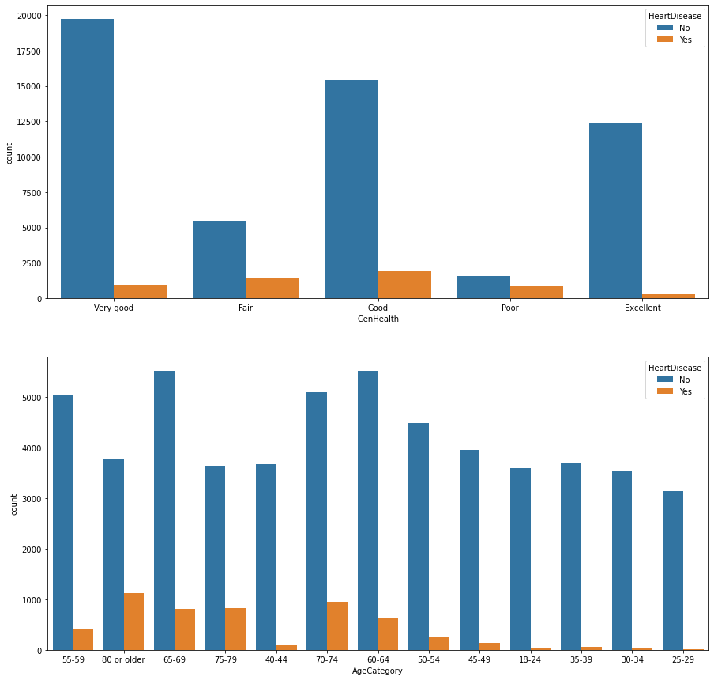

```python
f,ax = plt.subplots(2,1,figsize=(15,15))
sns.countplot(data=data,x='GenHealth',hue='HeartDisease',ax=ax[0])
sns.countplot(data=data,x='AgeCategory',hue='HeartDisease',ax=ax[1])
```

Nhận xét: Qua 2 biểu đồ trên ta có thể thấy được người có sức khỏe chưa tốt và người lớn tuổi có khả năng mắc bệnh tim cao hơn

```python
def Draw_pie_chart(name_feature):

    fig,axes = plt.subplots(1,2,figsize=(15,8))
    labels = data[name_feature].unique()
    textprops = {"fontsize":15}

    axes[0].pie(data[data.HeartDisease=="No"][name_feature].value_counts(), labels=labels,autopct='%1.1f%%',textprops =textprops)
    axes[0].set_title('No Heart Disease',fontsize=15)
    axes[1].pie(data[data.HeartDisease=="Yes"][name_feature].value_counts(), labels=labels,autopct='%1.1f%%',textprops =textprops)
    axes[1].set_title('Yes Heart Disease',fontsize=15)

    plt.legend(title = name_feature, fontsize=15, title_fontsize=15)
    plt.show()
```

### Biểu đồ tròn thể hiện việc hút thuốc lá có ảnh hưởng đến bị bệnh tim hay không

[figure not shown]

```python
Draw_pie_chart("Smoking")
```

Nhận xét: Dữ liệu này không cân bằng vì chưa tới 9% người mắc bệnh tim. Tuy nhiên, trong hai biểu đồ tròn này thì tỷ lệ giữa những người hút thuốc và không hút thuốc đều có tỷ lệ mắc bệnh tim gần như bằng nhau. Vì vậy ta có thể kết luận việc hút thuốc lá khổng ảnh hưởng đến bệnh tim hoặc còn có một biến ẩn nào đó mà ta chưa nhận ra.

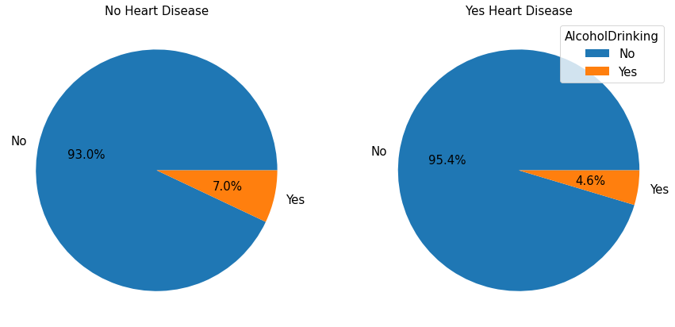

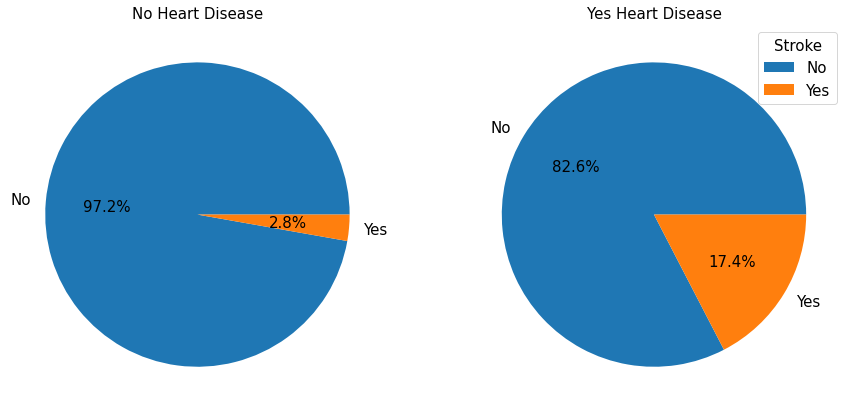

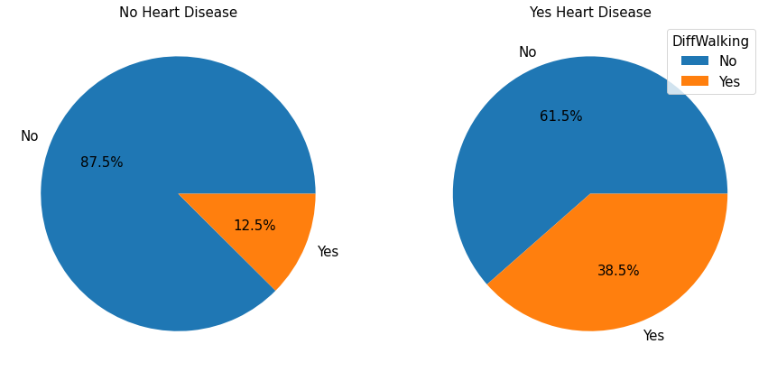

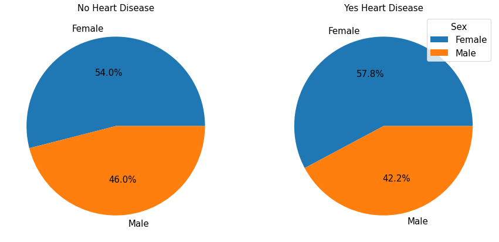

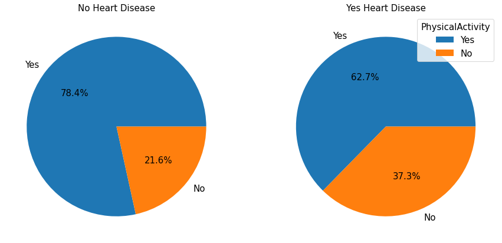

[figure not shown]

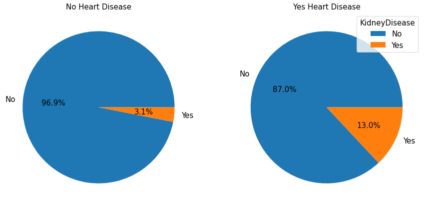

[figure not shown]

```python
binary_feature = []

for feature in data.columns:
    if np.isin(data[feature].unique(),["Yes","No"]).all() or np.isin(data[feature].unique(),["Male","Female"]).all():
        binary_feature.append(feature)

for feature in binary_feature[2:]:
    Draw_pie_chart(feature)
```